# First simulations

Arnie Seong

22 October 2024

# Background

The motivation for this model is to combine the variable selection properties of Bayesian spike-and-slab with the expressivity of a neural network. We do this by placing a spike-and-slab prior on the *rows* of a weight matrix $W$ representing one layer of a neural network.

Let $X$ be a $n \times I$ matrix representing $n$ observations of $I$ covariates, and $W$ be a $I \times J$ weight matrix. We can then represent the computation performed by the first (input) layer of a neural network as $XW + b = H$, where $b$ is a length $J$ vector of biases (which is duplicated $n$ times into a $n \times J$ matrix) and $H$ is the pre-activation (that is, if $\sigma ()$ denotes the activation function, $\sigma(H) = \tilde{H}$ is the input for the next layer in the neural network).

If all of the weights $w_{ij}$ in row $i$ of $W$ are 0, then the covariate in column $i$ of $X$ does not contribute to $H$ and therefore also has no effect on the final prediction. Thus by placing a spike-and-slab prior on the rows of $W$, we obtain variable selection.

We rely heavily here on the formulation and variational Bayes algorithm developed by *Louizos, Ullrich, Welling 2017*, who proposed using a group sparsity prior in order to reduce the size of the weight matrices in a neural network. Their primary focus is on decreasing the size of the neural network while preserving quality of prediction — the method leads to compression of the neural network since if an entire row or column of weights is 0, then the dimension of the weight matrix can be reduced. Accordingly, their discussion of how to tune what they term “the dropout parameter” ($\alpha_i$), is based around desired compression rates rather than how to use it for principled variable selection.

## notes:

**How to differentiate ourselves from LUW 2017**:

- Need to experiment to see if it’s better to only do this for the input layer (as opposed to all layers, which is the current implementation)
- a more rigorous interpretation of the dropout parameter $\alpha_i$ as the equivalent to a Wald statistic
- (Adam’s paper) using normalizing flow to model non-local prior
- some way to reconcile mean-field assumption of Variational Bayes with group sparsity?
- as *LUW 2017* note, the log-uniform prior does require independence between parameters (i.e. grouping by row is not kosher), so the joint Bayesian model developed in LUW 2017 is not strictly accurate and is more of an approximation
- obvious difference: provide empirical results on how good the method is at variable selection

**Note on indices**:

$i \in \{1, 2, ..., I\}$ indexes the rows of the weight matrix $W$, i.e. the inputs or covariates. $j \in \{1, 2, ...., J\}$ indexes the columns of $W$, i.e. the output’s dimensionality. Thus, representing a fully connected layer of a neural network as $XW + b = H$, the components are:

- $X$: $n \times I$ matrix of covariates ($n$ observations of $I$ covariates)
- $W$: $I \times J$ weight matrix
- $b$: length $J$ intercept vector (gets “broadcast”, i.e. duplicated and stacked/rowbound to form a $n \times J$ matrix)
- $H$: $n \times J$ pre-activation

In a single-layer neural network, $H$ is our prediction $\hat{y}$.  
In a multi-layer neural network, $H$ passes through some activation function $\sigma()$. This $\sigma(H) = \tilde H$ then becomes the input for the next layer.

# Model

We adopt a scale mixture of Normals as the prior for the weights:

$$\begin{align}
z
& \sim p(z)
\\
w
& \sim N(0, z^2)
\end{align}$$

This is a fairly general formulation: letting $p(z)$ be Bernoulli, for example, leads to the discrete spike-and-slab.

Following LUW 2017, we make two modifications:

1. we use the log-uniform prior for $z$, corresponding to a continuous relaxation of the discrete spike-and-slab;
2. rather than assigning each individual weight $w_{ij}$ its own $z_{ij}$, we constrain each row of weights $w_{i \cdot}$ to share a single $z_i$, thus enforcing group sparsity.

Under this formulation, the Bayesian model is:

$$\begin{align}
p(z_{i}) &\propto |z_{i}|^{-1}
\\
p(w_{ij} | z_{i}) &= N(w_{ij} | 0, z_{i}^2)
\end{align}$$

And therefore we have:

$$\begin{align}
p(W, \mathbf{z})
&= \prod_i \frac{1}{|z_i|}\prod_{i,j} N(w_{ij} | 0, z_{i}^2)
\end{align}$$

In order to avoid MCMC on the potentially very large number of parameters, we adopt *LUW 2017*’s variational Bayes algorithm (in turn adapted from *Kingma, Salimans, Welling 2015* and *Molchanov, Ashukha, Vetrov 2017*). Thus, we use the variational distribution

$$\begin{align}
q(W, z)
&= \prod_{i} N \left(z_{i} | \mu_{z_{i}}, \mu_{z_{i} }^2
\alpha_{i} \right)
\prod_{i,j} N \left( w_{ij} | z_{i} \mu_{ij}, z_{i}^2
\sigma_{ij}^2 \right)
\end{align}$$

where $\alpha_i$ is the dropout rate of a given row of weights. Furthermore, following *Molchanov, Ashukha, Vetrov 2017*, we reparameterize $\mu_{z_{i} }^2 \alpha_{i} = \sigma_{z_i}^2$ because the approximate posterior over $z$ suffers from high variance gradients. Thus we arrive at the the variational distribution:

$$\begin{align}
q(W, z)
&= \prod_{i} N \left(z_{i} | \mu_{z_{i}},
{\color{red}{\sigma_{z_i}^2}} \right)
\prod_{i,j} N \left( w_{ij} | z_{i} \mu_{ij}, z_{i}^2
\sigma_{ij}^2 \right)
\end{align}$$

**One important item to notice here:** the (now implied) dropout parameter $\alpha_{i} = \dfrac{\sigma_{z_i}^2}{\mu_{z_i}^2}$ is the inverse of a Wald statistic for $z_i$. *(Perhaps this being a Wald statistic is just so obvious it doesn’t need mentioning, but I don’t believe any of the the papers positing this as a dropout parameter say this explicitly)* This might be used to provide guidance on how to threshold $\alpha_{i}$ appropriately for variable selection (LUW2017 only addresses thresholding $\alpha_i$ in order to achieve a desired level of compression).

### need help here

From what I can tell, the full formulation appears to be (letting $f(W,X)$ denote the function of the covariates $X$ parameterized by the neural network’s weights $W$):

$$\begin{align}
y & \sim N(y; f(W, X), \sigma^2)
\\
p(W | z) &= \prod_{ij} p(w_{ij} | z_i) = \prod_{ij} N \left(w_{ij}
| 0, z_{i}^2 \right)
\\
p(z) &= \prod_i p(z_{i}) \propto \prod_{ij} |z_{i}|^{-1}
\\
\end{align}$$

And the variational distributions (based on code):

$$\begin{align}
q(W, z)
&= \prod_{i} N \left(z_{i} | \mu_{z_{i}},
{\color{red}{\sigma_{z_i}^2}} \right)
\prod_{i,j} N \left( w_{ij} | z_{i} \mu_{ij}, z_{i}^2
\sigma_{ij}^2 \right)
\\
\mu_{ij} &\sim N(0,1/J)
\\
\sigma_{ij}^2 &\sim logNormal(-9, 0.01)
\\
\mu_{z_i} &\sim N(0, 1/I)
\\
\sigma_{z_i}^2 &\sim logNormal(-9, 0.01)
\\
\alpha_{i} &= \dfrac{\sigma_{z_i}^2}{\mu_{z_i}^2}
\end{align}$$

A few things that I do not understand are:

1. the model for the data, i.e. $y \sim N(y; f(W, X), \sigma^2)$, is never addressed in *LUW 2017*. I feel like I’m missing something fundamental here — none of the literature appears to address this.
- the only place that a distributional model for the data is mentioned is in the ELBO, $\mathcal{L}(\phi) = E_{q_\phi(W|z) q_\phi(z)} \left[ \log \color{red}{p(y|W, z)} \right] - E_{q_\phi(z)} \left[ KL\left( q_\phi(W|z) || p(W|z) \right) \right]-KL \left(q_\phi(z) || p(z) \right)$.
- it seems like this likelihood term simply gets replaced by MSE in the scalar response case (which would comport with an assumption that $y \sim N(f(W, X), \sigma^2)$, at least up to a multiplier), or cross-entropy when the data/response are pictures/labels (again, corresponding to an assumed multinomial dist’n). This makes sense to me, BUT what doesn’t make sense is that 1) the variance of the response is not modeled anywhere, and 2) the multiplier probably matters a little, no?
2. the priors for many parameters in the variational distribution are never mentioned in the paper / left implicit — in particular, the priors placed on $\mu_{z_i}, \alpha_i, \mu_{ij}, \sigma_{ij}^2$.
- The code makes draws from Normal and log-Normal distributions *to initialize* $\mu_{z_i}, \alpha_i, \mu_{ij}, \sigma_{ij}^2$, and these parameters are updated via the gradient of the ELBO. However, their distributions are not part of the computation. I suppose these parameters are only part of the *variational* distribution, and so … their distributions don’t actually matter much? We’re just trying to optimize the ELBO using them?

## multiple layers

In a deep neural network (i.e. with more than 1 layer), we place the sparsity prior on every layer (investigation whether results are better if only placing the sparsity prior on the first layer may be warranted, however). Other than requiring another index $l$ denoting the layer, the formulation is similar:

Let $l$ index the layer of the weight matrix $W_l$ (here, $l \in \{1, 2\}$), and $i$ index the row of $W_l$, and $j$ index the columns. The Bayesian model $p(w_{lij} | z_{l i \cdot} p(z_{l i \cdot})$ and variational distribution $q(W_l, z)$ are:

$$\begin{align}
p(z_{li \cdot}) &\propto |z_{li \cdot}|^{-1}
\\
p(w_{lij} | z_{l i \cdot}) &= N \left(w_{lij} | 0, z_{l i \cdot}^2
\right)
\\
q(W_l, z) &= \prod_{l, i} N \left(z_{li \cdot} | \mu_{z_{l i
\cdot}}, \mu_{z_{l i \cdot} }^2 \alpha_{l i \cdot} \right) \prod_{l,i,j}
N \left( w_{lij} | z_{l i \cdot} \mu_{lij}, z_{l i \cdot}^2
\sigma_{lij}^2 \right)
\end{align}$$

The upshot of all of this is just that we can perform the same operations on each layer, and the results are easily separable (multiply / sum each layer’s results to get results for entire network)

# Derivations

## ELBO (general)

For notational simplicity, in the following I use $z$ to denote both the weights ($W$) and scale parameters ($z$), and $phi$ to denote all parameters governing the variational distribution ($\{\mu_{z_i}, \alpha_i, \sigma_{z_i}^2, \mu_{ij}, \sigma_{ij}^2\}$).

Deriving ELBO:

$$\begin{align}
KL\left(q_\phi(z) || p(z|x)\right)
&=
\sum_z q_\phi(z) \log \left( \dfrac{ q_\phi(z) }{ p(z|x) } \right)
\\
&=
\sum_z q_\phi(z) \log \left( q_\phi(z) \cdot \dfrac{ p(x) }{ p(z,x)
} \right)
\\
&=
\sum_z \left\{ q_\phi(z) \left( \log q_\phi(z) - \log p(z, x)
\right) \right\}
+ \sum_z q_\phi(z) \left( \log p(x) \right)
\\
&= \sum_z \left\{ q_\phi(z) \left( \log q_\phi(z) - \log p(z, x)
\right) \right\}
+ \log p(x)
&& \text{since } p(x) \text{ is constant w.r.t. } z
\\
\text{Thus } \log p(x)
&=
KL\left(q_\phi(z) || p(z|x) \right)
- \sum_z \left\{ q_\phi(z) \left( \log q_\phi(z) - \log p(z, x)
\right) \right\}
\\
&=
KL\left(q_\phi(z) || p(z|x) \right)
\underbrace{- E_{q_\phi(z)} \left[ \log q_\phi(z) - \log p(z, x)
\right]}_{ELBO}
\end{align}$$

The second term is the ELBO $\mathcal{L}(\phi)$. Since $\log p(x)$ is constant w.r.t. $q_\phi (z)$, maximizing the ELBO over $\phi$ minimizes the first term, the KL divergence between the variational distribution $q_\phi(z)$ and the posterior $p(z|x)$.

### Bayesian interpretation of ELBO

I mentioned a potentially interesting interpretation of the ELBO at our face-to-face meeting at the MoonGoat. Just wanted to follow up on this, mostly as a side note:

We can rearrange the above expression for the ELBO such that:
$$\begin{align}
\mathcal{L}(\phi)
&=
- E_{q_\phi(z)} \left[ \log q_\phi(z) - \log p(z, y) \right]
\\
&=
- E_{q_\phi(z)} \left[ \log q_\phi(z) - \log p(y|z) - \log p(z)
\right]
\\
&=
E_{q_\phi(z)} \left[\log p(y|z) \right] - E_{q_\phi(z)} \left[ \log
q_\phi(z) - \log p(z)\right]
\\
&=
E_{q_\phi(z)} \left[\log p(y|z) \right] - KL \left(q_\phi(z) ||
p(z)\right)
\end{align}$$

The first term is the log-likelihood integrated over $z$, whereas the second term is the KL divergence between the variational distribution $q_\phi(z)$ and the prior $p(z)$. In other words, the ELBO balances the expected likelihood of the data (under the variational distribution) against the expected “distance” between the variational distribution and the prior. As the variational distribution is our approximation to the posterior, we have a nice parallel here to the usual Bayesian idea of the data moving the posterior away from the prior.

A bit more rigorously: if we use the information theory interpretation of $\log \dfrac{1}{q_\phi(z)}$ as the “surprise” of drawing $z$ from the variational distribution $q_\phi(z)$, we can think of the terms as follows:

$$\begin{align}
\mathcal{L}(\phi)
&=
E_{q_\phi(z)} \left[\log p(y|z) \right] - KL \left(q_\phi(z) ||
p(z)\right)
\\
&=
-KL \left(q_\phi(z) || p(z)\right) - E_{q_\phi(z)} \left[\log
\dfrac{1}{p(y|z)} \right]
\end{align}$$

- $-KL \left(q_\phi(z) || p(z)\right)$ is the expectation, *when sampling $z$ from $q_\phi(z)$*, of how surprised we are by $z$ (given that we assume the variational distribution is true) minus how surprised we would have been by $z$ under the prior $p(z)$;
- $E_{q_\phi(z)} \left[\log \dfrac{1}{p(y|z)} \right]$ is the expected surprise of the data under our model *when $z$ is sampled under $q_\phi(z)$*.

So the ELBO, essentially, balances 1) the expected difference in surprise between the variational and prior distributions with 2) the expected surprise of the data, all when sampling $z$ under the variational distribution. So maximizing the ELBO involves minimizing the surprise of the data by adjusting the approximate posterior, while keeping the approximate posterior to the prior.

## derivations for this specific model

Reverting to previous notation ($W, z$ instead of just $z$), our last expression for the ELBO is:

$$\begin{align}
\mathcal{L}(\phi)
&=
E_{q_\phi(W, z)} \left[\log p(y|W, z) \right] -
KL \left(q_\phi(W, z) || p(W, z)\right)
\\
&=
E_{q_\phi(W|z) q_\phi(z)} \left[\log p(y|W, z) \right] -
E_{q_\phi(W|z) q_\phi(z)}\left[ \log \dfrac{q_\phi(W,z)}{p(W,z)}
\right]
\\
&=
E_{q_\phi(W|z) q_\phi(z)} \left[ \log p(y|W, z) \right] -
E_{q_\phi(z)} \left\{ E_{q_\phi(W|z)}\left[ \log
\dfrac{q_\phi(W|z)}{p(W|z)} + \log \dfrac{q_\phi(z)}{p(z)} \right]
\right\}
\\
&=
E_{q_\phi(W|z) q_\phi(z)} \left[ \log p(y|W, z) \right] -
E_{q_\phi(z)} \left[ KL\left( q_\phi(W|z) || p(W|z) \right) \right]-
KL \left(q_\phi(z) || p(z) \right)
\\
\end{align}$$

### Log-likelihood

Since $y$ depends on $z$ only through $W$, $p(y|W,z) = p(y|W)$. Thus the first term, $E_{q_\phi(W|z) q_\phi(z)} \left[ \log p(y|W, z) \right]$ is the expectation of the log-likelihood $\log p(y|W)$ under the variational distribution.

In the scalar response case, where the assumption appears to be (?) $p(y | W) = N(y; f(W, X), \sigma^2)$, we have

$$\begin{align}
\log p(y|W)
&=
-\frac{1}{2} \log (2 \pi \sigma^2)
-\frac{1}{2 \sigma^2} \left( y - f(W, X) \right)^2
\\
\end{align}$$

This portion of the ELBO, in the code, only appears as MSE. In other words, in the pytorch implementation posted on their github, LUW 2017 designates the objective function to be minimized as $MSE + KL\left( q_\phi(W|z) || p(W|z) \right) + KL \left(q_\phi(z) || p(z) \right)$.

So instead of the likelihood, the objective function only uses MSE. Leaving out $\frac{1}{2} \log (2 \pi \sigma^2)$ is fine, but what about the $\frac{1}{2 \sigma^2}$ multiplier on the $MSE$?

This seems problematic to me because this objective function is NOT an affine function of the ELBO (i.e. optimal parameter values will be different, no?).

### KL for W|z

Using the distributions for the weights

- $q_\phi(W|z) = \prod_{i,j} N(w_{ij} | z_i \mu_{ij}, z_i^2 \sigma_{ij}^2)$
- $p(W|z) = \prod_{i,j} N(w_{ij} | 0, z_i^2)$

we have:

$$\begin{align}
KL\left( q_\phi(W|z) || p(W|z) \right)
&=
E_{q_\phi(W|z)}
\left[
\log \dfrac{q_\phi(W|z)}{p(W|z)}
\right]
\\
&=
E_{q_\phi(W|z)}
\left[
\sum_{i,j} -\frac{1}{2}
\left(
\log(2\pi z_i^2 \sigma_{ij}^2)
+ \frac{(w_{ij} - z_i \mu_{ij})^2}{z_i^2 \sigma_{ij}^2}
-\log (2\pi z_i^2)
- \frac{w_{ij}^2}{z_i^2}
\right)
\right]
\\
&=
\frac{1}{2} E_{q_\phi(W|z)}
\left[
\sum_{i,j}
\left(
\log \frac{2 \pi z_i^2 }{2 \pi z_i^2 \sigma_{ij}^2}
- \frac{1}{z_i^2 \sigma_{ij}^2}
\left(
(1-\sigma_{ij}^2)w_{ij}^2 - 2 z_i \mu_{ij} w_{ij} + z_i^2
\mu_{ij}^2
\right)
\right)
\right]
\\
&=
\frac{1}{2}
\sum_{i,j}
\left(
\log \frac{1}{\sigma_{ij}^2}
- \frac{1}{z_i^2 \sigma_{ij}^2}
\left \{
(1-\sigma_{ij}^2) \left( E_{q_\phi(W|z)} \left[ w_{ij}^2
\right]\right)
- 2 z_i \mu_{ij} \left( E_{q_\phi(W|z)} [w_{ij}] \right)
+ z_i^2 \mu_{ij}^2
\right\}
\right)
\\
&=
\frac{1}{2}
\sum_{i,j}
\left(
\log \frac{1}{\sigma_{ij}^2}
- \frac{1}{z_i^2 \sigma_{ij}^2}
\left\{
(1-\sigma_{ij}^2) \left( z_i^2 \sigma_{ij}^2 + z_i^2
\mu_{ij}^2 \right) - 2 z_i^2 \mu_{ij}^2 + z_i^2 \mu_{ij}^2
\right\}
\right)
\\
&=
\dfrac{1}{2}
\sum_{i,j}
\left(
-\log \sigma_{ij}^2 + \sigma_{ij}^2 + \mu_{ij}^2 - 1
\right)
\end{align}$$

### KL for z

An approximation to $KL \left(q_\phi(z) || p(z) \right)$ is provided by $Molchanov, Ashukha, Vetrov 2017$:

$$KL \left(q_\phi(z) || p(z) \right)
\approx \sum_i (k_1 \sigma (k_2 + k_3 \log(\alpha_i))) - 0.5 m (-\log
\alpha_i) - k_3)$$
where $k_1 = 0.63576, k_2 = 1.87320, k_3 = 1.48695$; $\sigma$ is the sigmoid function; and $m$ is the softplus function. Importantly, note that this term depends only on the implied dropout rate $\alpha_i = \frac{\sigma_{z_i}^2}{\mu_{z_i}^2}$ — which we identified as having a form similar to a Wald statistic.

### optimization

Issue described below does not seem to be impacting results — as far as I can tell — but may lead to problems down the line?

We rely on torch’s automatic differentiation and gradient calculations to minimize the objective function. In the scalar response case, LUW 2017 and my current simulations use the objective function $MSE + KL/n$ (letting $KL$ stand in for both KL terms).

**Issue**: $MSE + KL/n$ contains the same components as the ELBO, but is not quite an affine function of the ELBO (i.e. optimal parameter values $\phi$ for the ELBO and for $MSE + KL/n$ are not necessarily the same, **which seems problematic**). In the ELBO, the terms estimated by the $MSE$ and $KL$ are scaled differently relative to each other, i.e.

$$\widehat{\mathcal{L}}(\phi) = -n \times
\left( \frac{MSE}{2 \sigma^2} + KL/n \right) + c$$
where $c$ is a constant not depending on $\phi$.

## other things to check:

- does the original code limit the range of $\alpha_i \in [0,1]$?
- the original code for *LUW 2017*”clips” variances —- what is this about?

# Simulations

Simulation settings:

1. response $y$ is linearly related to covariates $X$. 100 nuisance variables, 4 “true” covariates. n = 100.
1. `SLP` = single neuron model (i.e. basically a scale mixture of normals Spike-and-Slab on a linear regression model)
2. `MLP` = multiple neurons, multiple layers
   - 2 hidden layers with 50 nodes and 25 nodes respectively
2. response $y$ is non-linearly related to covariates $X$. 96 nuisance variables, 4 “true” covariates. Model used is identical to the one labeled `MLP` above.

## setting 1a)

*Linearly-related data, single neuron model*

**Data generation:**

- **Covariates**: $\vec{x}_i \sim N(0, I)$ for $i \in \{1, 2, ..., I\}$. $I$ is the number of covariates (what we usually denote using $p$); essentially, every entry in the matrix $X_{n \times I}$ is iid N(0,1).
- **Response**: letting $\epsilon \sim N(0,1)$,
  $$y = -0.5 x_1 + 1 x_2 - 2 x_3 + 4 x_4 +
  \epsilon$$
  i.e. only 4 “true” covariates ($x_1, x_2, x_3, x_4$) and 100 nuisance variables ($x_5, x_6, ..., x_{104}$)
- **number of observations** $n$ = 100
- **error variance** $\sigma^2$ = 1

**Model:**

`SLP` has only 1 neuron, i.e. we are essentially fitting a scale mixture of normals regression model.

Results averaged from running methods on 100 simulated datasets

```r
get_restab <- function(res, tru, log_alpha_threshold = -3, method_name = "Bnn", verbose = TRUE){
  require(Matrix)

  if (verbose){
    txt <- paste0("log_alpha_threshold = ", log_alpha_threshold,
              " (i.e. dropout rate of <",
              round(exp(log_alpha_threshold), 5),
              " required for inclusion)")
    cat("\n", txt, "\n")
  }

  method_log_alphas <- t(sapply(res, function(X) X[[1]]$log_dropout_alphas))
  method_include <- method_log_alphas < log_alpha_threshold

  method_binary_err <- t(apply(
    method_include, 1,
    function(X) binary_err(est = X, tru = tru)
  ))
  method_binary_err_rates <- t(apply(
    method_include, 1,
    function(X) binary_err_rate(est = X, tru = tru)
  ))

  method_fwer <- mean(method_binary_err_rates[,1] != 0)

  # other metrics
  method_metrics <- t(sapply(res, function(X) X[[1]]$other_metrics))

  # # # # # # # # # # # # # # # # # # # # # # # # #
  ## LASSO ----
  # # # # # # # # # # # # # # # # # # # # # # # # #

  lasso_coefs <- t(sapply(res, function(X) as.vector(X$lasso$coefs)[-1]))
  lasso_include <- lasso_coefs != 0
  lasso_binary_err_rates <- t(apply(
    lasso_include, 1,
    function(X) binary_err_rate(est = X, tru = tru)
  ))

  lasso_fwer <- mean(lasso_binary_err_rates[,1] != 0)


  # # # # # # # # # # # # # # # # # # # # # # # # #
  ## Spike-&-Slab ----
  # # # # # # # # # # # # # # # # # # # # # # # # #

  # use same threshold?


  ss_post_inclusion_probs <- t(sapply(res, function(X) X$ss$coefs[, 5]))
  ss_dropout_equiv <- 1 - ss_post_inclusion_probs
  ss_include <- ss_dropout_equiv < exp(log_alpha_threshold)


  ss_binary_err_rates <- t(apply(
    ss_include, 1,
    function(X) binary_err_rate(est = X, tru = tru)
  ))

  ss_fwer <- mean(ss_binary_err_rates[,1] != 0)

  method_res <- colMeans(method_binary_err_rates)
  ss_res <- colMeans(ss_binary_err_rates)
  lasso_res <- colMeans(lasso_binary_err_rates)


  method_fwer <- mean(method_binary_err_rates[,1] != 0)
  ss_fwer <- mean(ss_binary_err_rates[,1] != 0)
  lasso_fwer <- mean(lasso_binary_err_rates[,1] != 0)

  method_res <- c(method_res, "FWER" = method_fwer)
  ss_res <- c(ss_res, "FWER" = ss_fwer)
  lasso_res <- c(lasso_res, "FWER" = lasso_fwer)

  restab <- rbind(
    method_res,
    ss_res,
    lasso_res
  )

  rownames(restab) <- c(method_name, "Spike-Slab", "LASSO")
  colnames(restab) <- c("FP", "TP", "FN", "TN", "FWER")

  return(restab)
}



get_mses <- function(res, method_name = "Bnn"){

  mse_stats <- function(res_MSEs){
    c(
      "fit_MSE_avg" = mean(res_MSEs[, 1]),
      "fit_MSE_sd" = sd(res_MSEs[, 1]),
      "coef_MSE_avg" = mean(res_MSEs[, 2]),
      "coef_MSE_sd" = sd(res_MSEs[, 2])
    )
  }

  #mlnj average MSE
  method_metrics <- t(sapply(res, function(X) X[[1]]$other_metrics))
  method_MSEs <- method_metrics[, c(2,4)]
  lasso_MSEs <- t(sapply(res, function(X) c(X$lasso$fit_mse, X$lasso$coef_mse)))
  ss_MSEs <- t(sapply(res, function(X) c(X$ss$fit_mse, X$ss$coef_mse)))
  method_mse_vec <- mse_stats(method_MSEs)
  lasso_mse_vec <- mse_stats(lasso_MSEs)
  ss_mse_vec <- mse_stats(ss_MSEs)

  mse_tab <- rbind(
    method_name = method_mse_vec,
    "Spike-Slab" = ss_mse_vec,
    "LASSO" = lasso_mse_vec
  )
  return(mse_tab)
}
```

```r
fpath <- here("Rcode", "results", "linear_sim_sig1.Rdata")
load(fpath)

true_coefs = c(-0.5, 1, -2, 4, rep(0, times = 100))
tru <- true_coefs != 0



# slnj bare results

# threshold log_alphas at -3 (exp(-3) \approx 0.05)
# what is a reasonable dropout probability?
log_alpha_threshold <- -3
txt <- paste0("log_alpha_threshold = ", log_alpha_threshold,
              " (i.e. dropout rate of <",
              round(exp(log_alpha_threshold), 5),
              " required for inclusion)")

slnj_tab <- get_restab(
  res = res,
  tru = tru,
  log_alpha_threshold = log_alpha_threshold,
  method_name = "SLP",
  verbose = FALSE
)

mykable(tab = slnj_tab, cap = "SLP results")
```

SLP results

|  | FP | TP | FN | TN | FWER |
| --- | --- | --- | --- | --- | --- |
| SLP | 0.0017 | 0.9575 | 0.0425 | 0.9983 | 0.16 |
| Spike-Slab | 0.0000 | 0.8525 | 0.1475 | 1.0000 | 0.00 |
| LASSO | 0.0295 | 0.9875 | 0.0125 | 0.9705 | 0.76 |

Model inclusion for `SLP` decided using the “implied dropout parameter” $\alpha_i$.  
log_alpha_threshold = -3 (i.e. dropout rate of <0.04979 required for inclusion)

Model fit results measured in terms of MSE are in the table below. Reported MSE for Spike-and-Slab models are calculated using each trial’s posterior means only (i.e. each trial’s `fit_MSE` and `coef_MSE` are calculated using the posterior means for the coefficients. The mean and sd of these across trials are then calculated.)

```r
mse_tab <- get_mses(res, method_name = "SLP")
mykable(tab = round(mse_tab, 4), cap = "fit metrics")
```

fit metrics

|  | fit_MSE_avg | fit_MSE_sd | coef_MSE_avg | coef_MSE_sd |
| --- | --- | --- | --- | --- |
| method_name | 0.7821 | 0.1123 | 0.2643 | 0.1260 |
| Spike-Slab | 1.0452 | 0.1752 | 0.1218 | 0.0021 |
| LASSO | 1.4010 | 0.2414 | 0.0037 | 0.0017 |

I’m looking at the MSE’s and realizing that I did not apply the dropout before calculating the coefficient MSE. So for both the Spike-and-Slab and for our models, the MSEs use the estimated posterior mean even when the decision was to drop the variable from the model (instead of 0). This applies to the next batch of results as well. Unfortunately I did not save the network weights, so cannot recalculate it.

## setting 1b)

**Data generation**: identical to setting 1a).

**Model**: `MLP` = multiple neurons, multiple layers

- 2 hidden layers with 50 nodes and 25 nodes respectively

```r
fname <- "MLP_linear_sim_sig1.Rdata"
fname2 <- "MLP_linear_sim_sig1_part2.Rdata"
fpath <- here::here("Rcode", "results", fname)
fpath2 <- here::here("Rcode", "results", fname2)

load(fpath)
load(fpath2)

# some results null (stopped simulation b/c needed to use computer)
res_non_null <- res[!sapply(res, is.null)]
result_non_null <- result[!sapply(result, is.null)]

res <- append(res_non_null, result_non_null)

# replace with true coefs
tru <-c(rep(1, 4), rep(0, 100))

mlnj_tab <- get_restab(
  res = res,
  tru = tru,
  log_alpha_threshold = log_alpha_threshold,
  method_name = "MLP",
  verbose = FALSE
)

mykable(tab = mlnj_tab, cap = "MLP results")
```

MLP results

|  | FP | TP | FN | TN | FWER |
| --- | --- | --- | --- | --- | --- |
| MLP | 0.00296 | 0.95 | 0.05 | 0.99704 | 0.240 |
| Spike-Slab | 0.00000 | 0.86 | 0.14 | 1.00000 | 0.000 |
| LASSO | 0.03016 | 0.99 | 0.01 | 0.96984 | 0.728 |

The highly over-parameterized version of this model still performs quite well in terms of variable selection for linear data.

Below are metrics for the model fit. Included are the coefficient MSEs, though they are not really relevant for the `MLP` (calculated based on input layer’s coefficients for these variables, but there are 2 hidden layers in the neural network).

```r
mse_tab <- get_mses(res, method_name = "MLP")
mykable(tab = round(mse_tab, 4), cap = "fit metrics")
```

fit metrics

|  | fit_MSE_avg | fit_MSE_sd | coef_MSE_avg | coef_MSE_sd |
| --- | --- | --- | --- | --- |
| method_name | 0.8248 | 0.1262 | 223.8268 | 450.3968 |
| Spike-Slab | 1.0257 | 0.1692 | 0.0251 | 0.0486 |
| LASSO | 1.3716 | 0.2313 | 0.0035 | 0.0014 |

### comments

**Setting 1a) (linear data, single neuron model)** is largely meant as proof of concept.

- The results of the `SLP` and the `Spike-Slab` models should be similar, since fitting the `SLP` model corresponds to a fitting Spike-and-Slab model with 2 modifications: 1) the discrete Spike-and-Slab model has been relaxed to a scale-mixture of Gaussians, 2) rather than MCMC, a variational algorithm is employed to find optimal parameter values.
- results are encouraging. Both `SLP` and `Spike-Slab` are more conservative than LASSO, with only a very small loss in power. `Spike-Slab` is more conservative than `SLP`, but has a somewhat large loss in power.
- lowest fit MSE. `SLP` Appears to be overfitting a bit (since we’d expect the fit MSE to be $\approx 1$)

**Setting 1b) (linear data, deep neural network)**: the intention here is to show that simply using the intended form of our method will still work fine with data in which we have more covariates than observations AND the relationship between the response and true covariates is simple (linear) — i.e. even though the deep neural network is highly overparameterized for the data, we still maintain competitive performance in terms of both variable selection and fit.

- results are again quite encouraging. Only a very small loss in performance: though the False Positive Rate is about 2x as large as the previous (and precisely minimally parameterized) version of the model, we are still well within desirable limits (by like an order of magnitude).
- same comments regarding fit MSE (lowest, may be slightly overfitting?)

**FWER** is somewhat concerning in both settings, but I’m not sure what a “good” FWER is when we have 100 nuisance variables but only 4 “true” covariates.

**Note**: we might employ a more sophisticated method for setting the inclusion threshold for the dropout parameter $\alpha_i$. Right now inclusion criteria for the `SLP` and `MLP` methods are based on setting the threshold (approximately) at $\alpha_i < 0.05$. (For the Spike-and-Slab models, posterior inclusion probability threshold is set to 0.95 to be included in the model).

## setting 2

**Data generation**:

- **covariates**: identical to setting 1a), except upped the number of observations to 10,000 observations.
- **response**:
  - non-linear relationship between response $y$ and $x_1, x_2, x_3, x_4$:
    $$y = f_1(x_1) +
    f_2(x_2) + f_3(x_3) + f_4(x_4) + \epsilon$$
    with $\epsilon \sim N(0,1)$. Below is a plot showing $f_1(x), f_2(x), f_3(x), f_4(x)$ (plotted using same x-coords to fit in 1 plot).

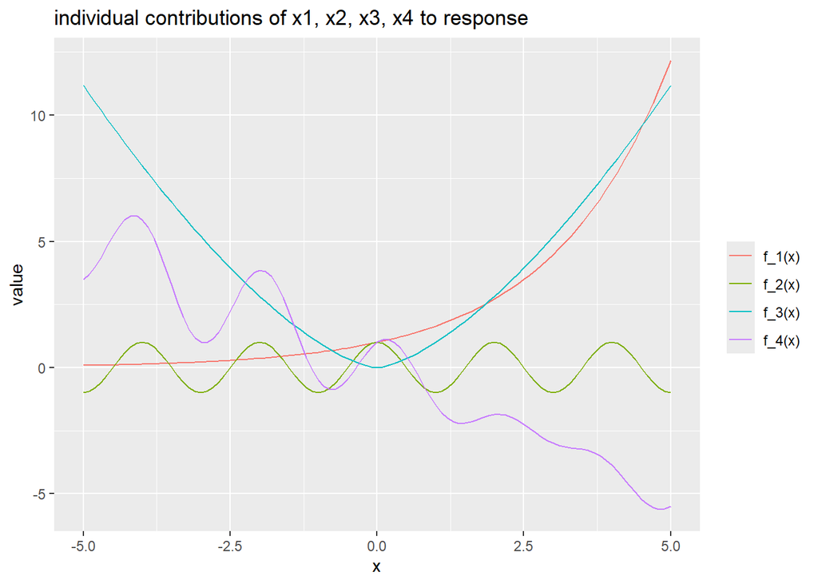

```r
x_grid <- -50:50 / 10
y1 <- fcn1(x_grid)
y2 <- fcn2(x_grid)
y3 <- fcn3(x_grid)
y4 <- fcn4(x_grid)

fcn_df <- data.frame(
  x_grid, y1, y2, y3, y4
)

names(fcn_df) <- c(
  "x",
  "f_1(x)",
  "f_2(x)",
  "f_3(x)",
  "f_4(x)"
)


fcn_df %>%
  pivot_longer(cols = -x) %>%
  ggplot() +
  geom_line(
    aes(
      y = value,
      x = x,
      color = name
    )
  ) +
  labs(
    title = "individual contributions of x1, x2, x3, x4 to response",
    color = ""
  )
```

**Model**:

`MLP` = multiple neurons, multiple layers  
- 2 hidden layers with 50 nodes and 25 nodes respectively

```r
fname <- "MLP_fcnl_sim_sig1"
partial_fpaths <- here("Rcode", "results", paste0(fname, "_PARTIAL", 1:7, ".Rdata"))


fname_part2 <- "MLP_fcnl_sim_sig1_part2"
partial_fpaths_part2 <- here("Rcode", "results", paste0(fname_part2, "_PARTIAL", 1:5, ".Rdata"))

partial_fpaths_all <- c(partial_fpaths, partial_fpaths_part2)

mlnj_res <- list()

for (i in 1:length(partial_fpaths_all)){
  load(file = partial_fpaths_all[i])
  mlnj_res <- append(mlnj_res, partial_res)
}

tru <- c(rep(1, 4), rep(0, 96))

mlp_tab <- get_restab(res = mlnj_res, tru = tru, method_name = "MLP")
```

```
##
##  log_alpha_threshold = -3 (i.e. dropout rate of <0.04979 required for inclusion)
```

```r
mykable(tab = mlp_tab, cap = "MLP on functional data")
```

MLP on functional data

|  | FP | TP | FN | TN | FWER |
| --- | --- | --- | --- | --- | --- |
| MLP | 0.8361111 | 0.9520833 | 0.0479167 | 0.1638889 | 1 |
| Spike-Slab | 0.0000000 | 0.5000000 | 0.5000000 | 1.0000000 | 0 |
| LASSO | 0.0000000 | 0.5000000 | 0.5000000 | 1.0000000 | 0 |

These results are pretty bad.

### troubleshooting

```r
# # # # # # # # # # # # # # # # # # # # # # # # #
## troubleshooting ----
# # # # # # # # # # # # # # # # # # # # # # # # #
stop_reasons <- t(sapply(mlnj_res, function(X) X$mlnj$stop_reason))
stop_epoch <- sapply(mlnj_res, function(X) X$mlnj$epoch)
stop_reasons[which(stop_epoch == max(stop_epoch)), 1] <- TRUE
colSums(stop_reasons)
```

```
##    max_epochs converge_crit       loss_ma
##             4           116             0
```

Most stop b/c met convergence criteria. A few stop b/c max epochs reached. Convergence criteria appears to be too easy to meet?

Also, perhaps setting the prior at $E[alpha_i] = 0.5$ is making it take a longer time to converge. Perhaps setting the prior to reflect that we think the truth is sparse will help.

**looking at thresholding for alpha**:

Below are summaries of $\log(\alpha_i)$ for the 4 true covariates:

```r
# alphas of true covariates
log_alpha_mat <- t(sapply(mlnj_res, function(X) X$mlnj$log_dropout_alphas))
summary(log_alpha_mat[, 1:4])
```

```
##        x1                x2                x3                x4
##  Min.   :-10.069   Min.   :-10.188   Min.   :-11.359   Min.   :-12.588
##  1st Qu.: -9.478   1st Qu.: -6.001   1st Qu.:-11.133   1st Qu.:-12.083
##  Median : -9.251   Median : -5.105   Median :-10.798   Median :-11.705
##  Mean   : -8.965   Mean   : -4.607   Mean   :-10.341   Mean   :-11.242
##  3rd Qu.: -8.424   3rd Qu.: -4.058   3rd Qu.: -9.518   3rd Qu.:-10.449
##  Max.   : -7.462   Max.   :  6.898   Max.   : -8.467   Max.   : -9.002
```

The expectation was that $f_2(x_2)$ would be the hardest to learn (it’s a sine wave), and that appears to be true.

And below is a summary of the minimum values of the $\log(\alpha_i)$ for the nuisance variables:

```r
summary(apply(log_alpha_mat[, 5:100], 2, min))
```

```
##    Min. 1st Qu.  Median    Mean 3rd Qu.    Max.
##  -8.123  -7.290  -7.156  -7.180  -7.057  -6.770
```

So the good news is that there is a fair bit of separation between the values of $\log(\alpha_i)$ for the nuisance and true covariates, and that the separation is happening in the expected direction (lower values of $\alpha_i$ correspond to lower dropout / higher inclusion)

It appears the main difficulty might simply be figuring out how to set the alpha threshold?

```r
get_restab(res = mlnj_res, tru = tru, log_alpha_threshold = -7, method_name = "MLP", verbose = TRUE)
```

```
##
##  log_alpha_threshold = -7 (i.e. dropout rate of <0.00091 required for inclusion)
```

```
##                    FP          TP        FN        TN      FWER
## MLP        0.01215278 0.768750000 0.2312500 0.9878472 0.2666667
## Spike-Slab 0.00000000 0.004166667 0.9958333 1.0000000 0.0000000
## LASSO      0.00000000 0.500000000 0.5000000 1.0000000 0.0000000
```

Could also try ordering based on alpha:

```r
ord_alpha_mat <- apply(log_alpha_mat, 1, order)
ord_alpha_mat[1:4,]
```

```
##      [,1] [,2] [,3] [,4] [,5] [,6] [,7] [,8] [,9] [,10] [,11] [,12] [,13] [,14]
## [1,]    4    4    4    4    4    4    4    4    4     4     4     4     4     4
## [2,]    3    3    3    3    3    3    3    3    3     3     3     3     3     3
## [3,]    1    1    1    1    1    1    1    1    1     1     1     1     1     2
## [4,]   61   84   77   62   50   86   17    2   14    97    48     9    39     1
##      [,15] [,16] [,17] [,18] [,19] [,20] [,21] [,22] [,23] [,24] [,25] [,26]
## [1,]     4     4     4     4     4     4     4     4     4     4     4     4
## [2,]     3     3     3     3     3     3     3     3     3     3     3     3
## [3,]     1     1     1     1     1     1     1     1     1     1     1     1
## [4,]    75    43    61    54    14    47    12    25    94    72    36    22
##      [,27] [,28] [,29] [,30] [,31] [,32] [,33] [,34] [,35] [,36] [,37] [,38]
## [1,]     4     4     4     4     4     4     4     4     4     4     4     4
## [2,]     3     3     3     3     3     3     3     3     3     3     3     3
## [3,]     1     1     1     1     1     1     1     1     1     1     1     1
## [4,]    50     7    21    21    13    25    28    35     2    71   100    79
```

[output cut: 40 more lines]

Good news is that in every trial, true covariates have the 3 lowest $\alpha_i$ values. However, only a few are able to pick up on covariate $x_2$

```r
# what percentage get all 4 as having the lowest \alpha_i?
all4 <- apply(ord_alpha_mat, 2, function(X){
  sum(c(1:4) %in% X[1:4]) == 4
})
mean(all4)
```

```
## [1] 0.1
```

```r
# which trials get all 4 correct?
which(all4)
```

```
##  [1]   8  14  35  40  46  60  72  76  82  91 111 119
```

So only 1/10 of the trials get all 4 true covariates as having the lowest $\alpha_i$’s.

```r
# why did these simulations stop training?
all4_inds <- which(all4)
stop_reasons[all4_inds, ]
```

```
##       max_epochs converge_crit loss_ma
##  [1,]      FALSE          TRUE   FALSE
##  [2,]      FALSE          TRUE   FALSE
##  [3,]      FALSE          TRUE   FALSE
##  [4,]      FALSE          TRUE   FALSE
##  [5,]      FALSE          TRUE   FALSE
##  [6,]      FALSE          TRUE   FALSE
##  [7,]      FALSE          TRUE   FALSE
##  [8,]      FALSE          TRUE   FALSE
##  [9,]      FALSE          TRUE   FALSE
## [10,]      FALSE          TRUE   FALSE
## [11,]      FALSE          TRUE   FALSE
## [12,]      FALSE          TRUE   FALSE
```

None of these reached `max_epochs`, and instead reached the convergence criteria.

# Next Steps:

1. tweak training parameters (`convergence_crit`, `max_epochs`)
2. figure out how to set alpha threshold
- BH analog?
- figure out a Bayesian FDR metric?
1. need better competitors for the functional data analysis (VCBART? LASSO neural network?)
2. could also try to implement Adam’s model (normalizing flow with non-local prior)